# PA 2: Using Data Visualization to Find the Penguins

Author

Trycia Vong

```r
library(ggplot2)
library(palmerpenguins)
```

Download the .qmd template and save it in a reasonable location.

Today you will be exploring different types of visualizations to uncover which species of penguins reside on different islands.

Some advice:

- **Work with those around you.**
- If you aren’t sure how to make a specific plot or how to customize a plot, look over the class text for this week and make use of the [R graphics cheatsheet](https://manncz.github.io/stat331-calpoly-text/02-tidy-data-and-basics-of-graphics.html#rgraphics).
- Google is your friend! If you aren’t sure how to accomplish a certain task, type what you are trying to accomplish into Google and see what other people are saying.
  - Generally, adding `ggplot` to the end of your search will help make your search results more relevant!

## Getting Started

We will be creating visualizations using the `ggplot2` package.

For this activity, we will be exploring the `penguins` data from the `palmerpenguins` package, which has [fantastic documentation with really awesome artwork](https://allisonhorst.github.io/palmerpenguins/). So, you will need to install the **palmerpenguins** package.

`install.packages("palmerpenguins")`

**`install.packages()` in the console NOT in your `.qmd` file!**

You should type this into your console and NOT include it in a code chunk in your `.qmd` file. Recall that we only have to install a package **once**, but load it each time we open R. Each time you *render* your `.qmd` file, **ALL**the code chunks are run. Therefore, installing a package in a code chunk would cause R to unnecessarily install the package over and over again. Not good.

## Creating a Setup Code Chunk

1. Insert a code chunk at the beginning of your document (directly under the YAML).
2. Name the code chunk `setup`.
3. Use the hashpipe `#|` to specify a code chunk option that prevents any messages (e.g., from loading in packages) from appearing.
4. Load in the `tidyverse` or `ggplot2` package.
5. Load in the `palmerpenguins` package.

**Code chunk name: `setup`**

Naming your code chunk “setup” has special properties in a `.qmd` - specifically, this code chunk will run automatically when you try to run a subsequent code chunk. This ensures all packages and any other specifications for your document are loaded and will not cause you errors or messages.

## Dataset: `penguins`

I like to start by **seeing** the dataset I will be working with, so I am going to pull the `penguins` data into my R environment. Do you see it in the top right Environment tab?

```r
data(penguins)
```

You may notice that a dataset called `penquins_raw` also loaded. We will ignore this and focus on the `penguins` dataset.

6. Get to know your data. What are the variables and what units are they measured in? What does each row represent?

## Graphics

**Note**

Make sure to give your plots reader friendly axes labels!

**Note**

Make sure your final report **does not** display any warnings or messages from RStudio!

7. Use https://excalidraw.com/ (or pen and paper, a tablet, etc.) to create a **game plan** for a barchart of `species`, where `species` is mapped to the fill color of the barchart. Save or take a screenshot of your game plan – you will be uploading this to Canvas with your practice activity submission.
8. Use `ggplot2` to create the barchart you outlined above.

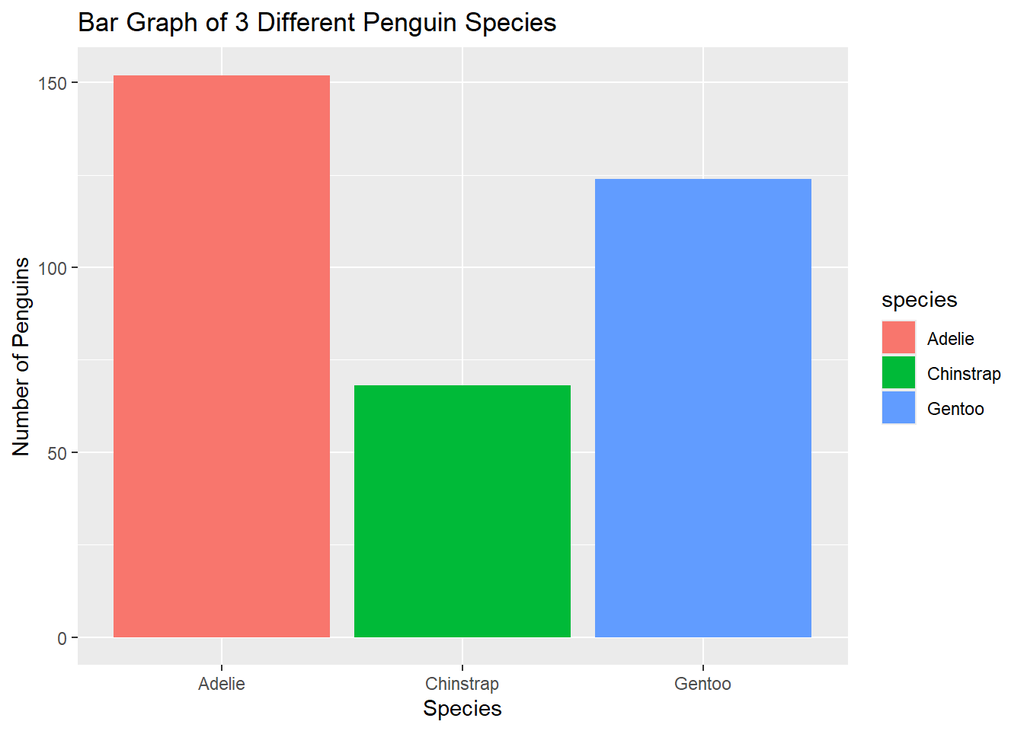

```r
ggplot(data = penguins, aes (x = species, fill = species)) +
  geom_bar() +
  labs (title = "Bar Graph of 3 Different Penguin Species", x = "Species", y = "Number of Penguins")
```

9. Use `ggplot2` to create a scatterplot of the relationship between the bill length (`bill_length_mm`) and bill depth (`bill_depth_mm`).

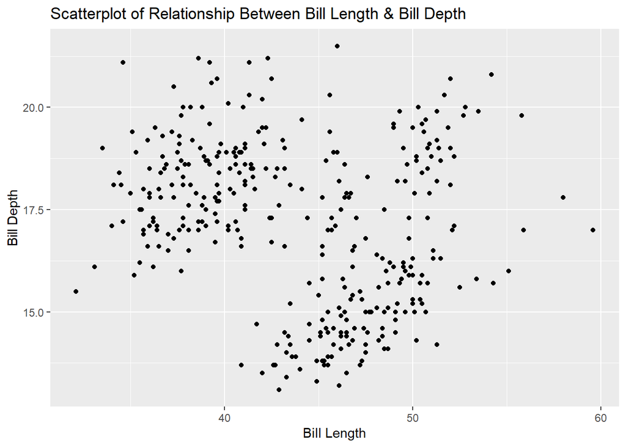

```r
ggplot(data = penguins, aes(x = bill_length_mm, y = bill_depth_mm)) +
  geom_point() +
  labs (title = "Scatterplot of Relationship Between Bill Length & Bill Depth", x = "Bill Length", y = "Bill Depth")
```

10. Building on your code from (9), add an aesthetic to differentiate the species by color.

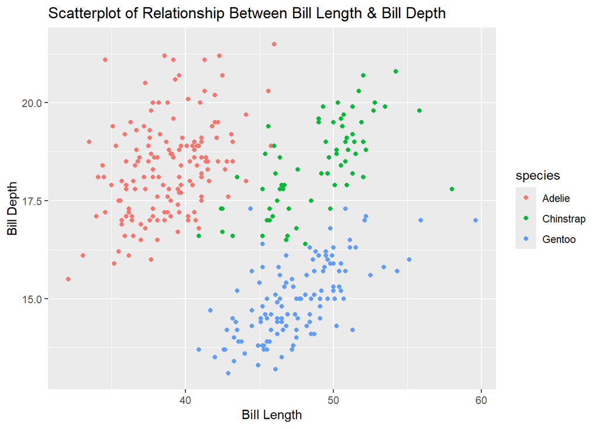

```r
ggplot(data = penguins, aes(x = bill_length_mm, y = bill_depth_mm, color = species)) +
  geom_point() +
  labs (title = "Scatterplot of Relationship Between Bill Length & Bill Depth", x = "Bill Length", y = "Bill Depth")
```

11. Building on your code from (10), add the location of the penguins (`island`) to your visualization. There us more than one way you could to address this, however, one method will make it easier to answer the questions below, so you might want to read those questions first!

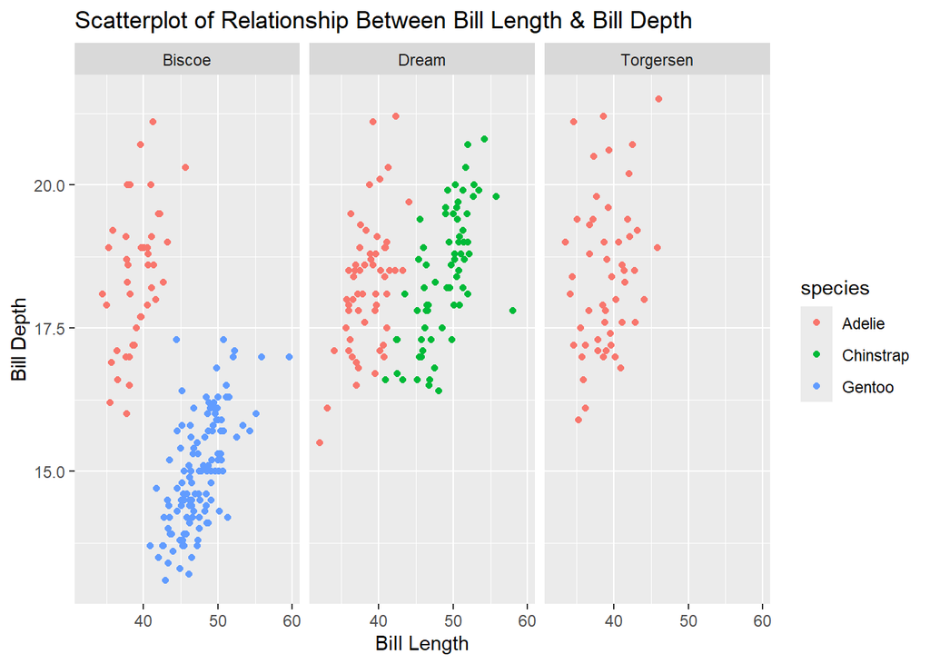

```r
ggplot(data = penguins, aes(x = bill_length_mm, y = bill_depth_mm, color = species)) +
  geom_point() +
  labs (title = "Scatterplot of Relationship Between Bill Length & Bill Depth", x = "Bill Length", y = "Bill Depth") +
  facet_wrap(vars(island))
```

## Canvas Quiz

**Use the plots you created to answer the following questions on Canvas.**

1. Which species of penguins is represented **least** in the Palmer Penguins data set?
2. Which species of penguins are found on **every** island?
3. Which species of penguins are found **only** on Dream Island?
4. Which species of penguins are found **only** on Biscoe Island?